# Time Series Model for [PROJECT NAME] Using Python Version 6

### 2.d) Box and Whisker Plots of the Time Series Data

We can group or aggregate the data and get a better idea of the spread of observations. Some observations from reviewing the plot can include:

- Whether the median values for each grouping shows any significant trend
- Whether the spread, or middle 50% of the data, shows any significant variability
- Whether there are outliers in some grouping

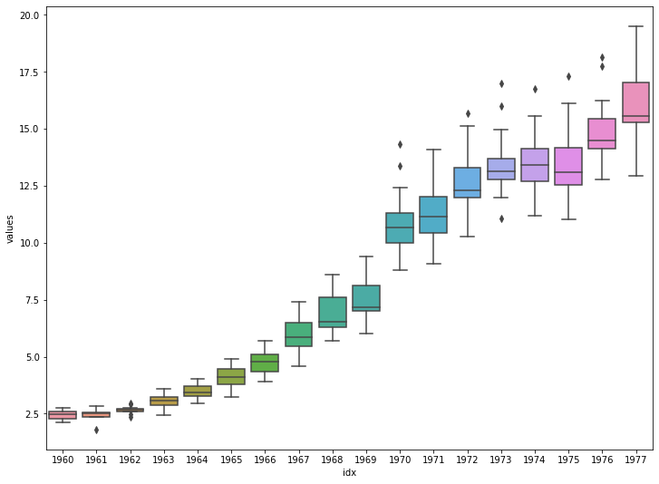

```python
# boxplots of time series
fig, ax = plt.subplots(figsize=(12,9))
squeezed = time_series.squeeze()
sns.boxplot(squeezed.index.year, squeezed, ax=ax)
plt.show()
```

```python
if (notifyStatus): email_notify("Data Inspection and Exploration completed! "+datetime.now().strftime('%a %B %d, %Y %I:%M:%S %p'))
```

## Section 3. Data Transformation and Stationarity Tests

```python
if (notifyStatus): email_notify("Data Cleaning and Pre-Processing has begun! "+datetime.now().strftime('%a %B %d, %Y %I:%M:%S %p'))
```

### Section 3.a) Data Transformation

```python
# Resampling the time series into monthly average for the ease of modeling
# original_series = time_series
# resample = original_series.resample('M')
# time_series = resample.mean()
# time_series.head(10)
```

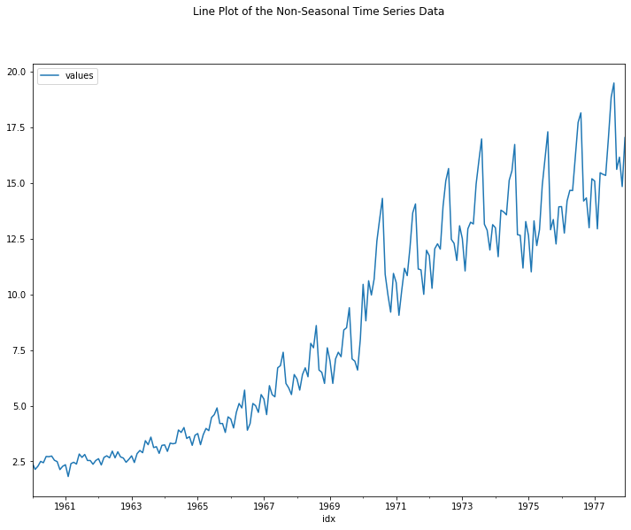

```python
# Line plots of the transformed time series
fig, ax = plt.subplots(figsize=(12,9))
fig.suptitle('Line Plot of the Non-Seasonal Time Series Data')
time_series.plot(ax=ax)
plt.show()
```

### Section 3.b) Test for Stationarity

```python
# Check if stationary
result = adfuller(time_series[target_col])
print('ADF Statistic: %f' % result[0])
print('p-value: %f' % result[1])
print('Critical Test Statistics Values:')
for key, value in result[4].items():
    print('\t%s: %.3f' % (key, value))
```

```
ADF Statistic: 0.315357
p-value: 0.978038
Critical Test Statistics Values:
	1%: -3.463
	5%: -2.876
	10%: -2.574
```

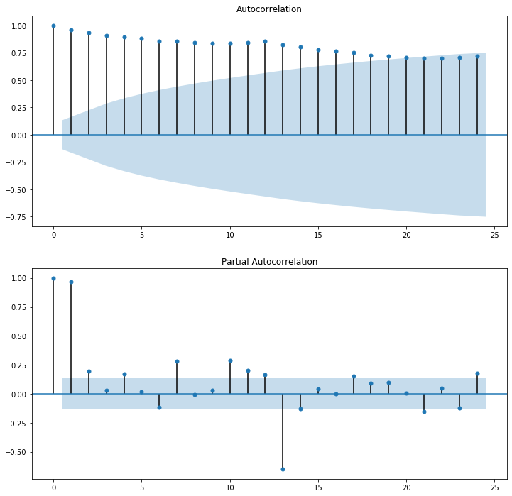

```python
# ACF and PACF plots of the time series data
fig, (ax1, ax2) = plt.subplots(2, 1, figsize=(12,12))
plot_acf(time_series, ax=ax1)
plot_pacf(time_series, ax=ax2)
plt.show()
```

### 3.c) Test for Stationarity of Non-Seasonal Time Series Data

Occasionally a time series may look non-stationary on the first look. We can make it stationary by differencing the series and using a statistical test to confirm that the differenced result is stationary. Rejecting the null hypothesis means that the process has no unit root, and in turn that the time series is stationary or does not have time-dependent structure.

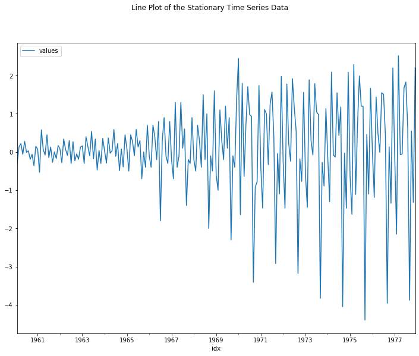

```python
# Create a differenced series
stationary_ns = time_series.diff().dropna()

# Plot differenced data
fig, ax = plt.subplots(figsize=(12,9))
fig.suptitle('Line Plot of the Stationary Time Series Data')
stationary_ns.plot(ax=ax)
plt.show()
```

```python
# Check for stationarity
result = adfuller(stationary_ns[target_col])
print('ADF Statistic: %f' % result[0])
print('p-value: %f' % result[1])
print('Critical Test Statistics Values:')
for key, value in result[4].items():
    print('\t%s: %.3f' % (key, value))
```

```
ADF Statistic: -3.748420
p-value: 0.003481
Critical Test Statistics Values:
	1%: -3.463
	5%: -2.876
	10%: -2.574
```

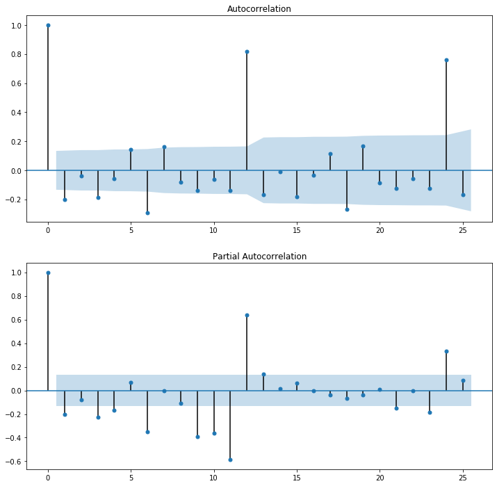

```python
# ACF and PACF plots of the stationary time series
lags = 25
fig, (ax1, ax2) = plt.subplots(2, 1, figsize=(12,12))
plot_acf(stationary_ns, lags=lags, ax=ax1)
plot_pacf(stationary_ns, lags=lags, ax=ax2)
plt.show()
```

### 3.d) Seasonal Decomposition for Seasonal Time Series Data

```python
# Set the initial seasonal frequency parameter
seasonal_freq = 12
```

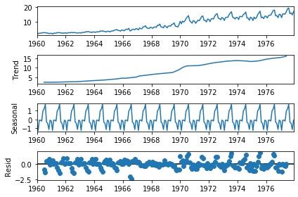

```python
# Perform seasonal decomposition to observe the seasonal frequency
decomp_results = seasonal_decompose(time_series, period=seasonal_freq)
decomp_results.plot()
plt.show()
```

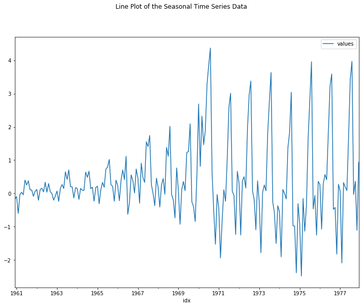

```python
# Create a seasonal series
N = seasonal_freq
seasonal_series = time_series - time_series.rolling(N).mean()
seasonal_series = seasonal_series.dropna()

# Line plots of the seasonal time series
fig, ax = plt.subplots(figsize=(12,9))
fig.suptitle('Line Plot of the Seasonal Time Series Data')
seasonal_series.plot(ax=ax)
plt.show()
```

```python
# Check for stationarity
result = adfuller(seasonal_series[target_col])
print('ADF Statistic: %f' % result[0])
print('p-value: %f' % result[1])
print('Critical Test Statistics Values:')
for key, value in result[4].items():
    print('\t%s: %.3f' % (key, value))
```

```
ADF Statistic: -3.996591
p-value: 0.001428
Critical Test Statistics Values:
	1%: -3.465
	5%: -2.877
	10%: -2.575
```

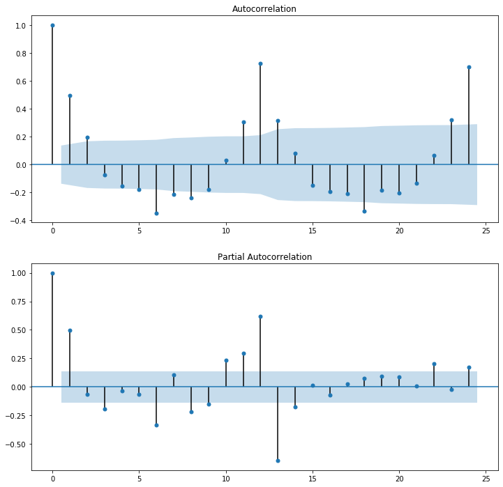

```python
# ACF and PACF plots of the time series data
lag = seasonal_freq * 2
fig, (ax1, ax2) = plt.subplots(2, 1, figsize=(12,12))
plot_acf(seasonal_series, lags=lag, ax=ax1)
plot_pacf(seasonal_series, lags=lag, ax=ax2)
plt.show()
```

### 3.e) Test for Stationarity of Seasonal Time Series Data

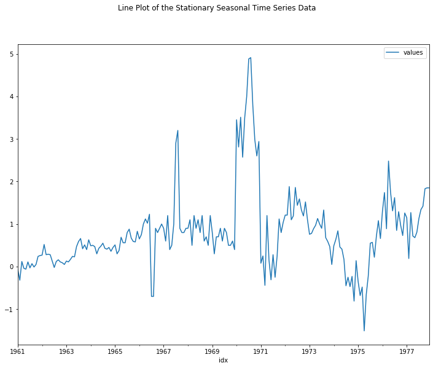

```python
# Create a differenced series
stationary_ss = time_series.diff(seasonal_freq).dropna()

# Plot differenced data
fig, ax = plt.subplots(figsize=(12,9))
fig.suptitle('Line Plot of the Stationary Seasonal Time Series Data')
stationary_ss.plot(ax=ax)
plt.show()
```

```python
# Check for stationarity
result = adfuller(stationary_ss[target_col])
print('ADF Statistic: %f' % result[0])
print('p-value: %f' % result[1])
print('Critical Test Statistics Values:')
for key, value in result[4].items():
    print('\t%s: %.3f' % (key, value))
```

```
ADF Statistic: -2.391473
p-value: 0.144157
Critical Test Statistics Values:
	1%: -3.465
	5%: -2.877
	10%: -2.575
```

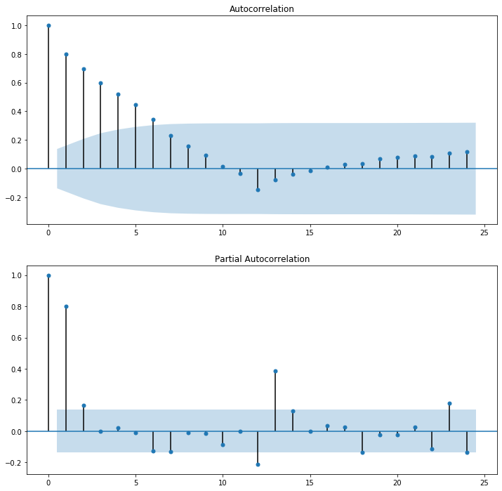

```python
# ACF and PACF plots of the stationary time series
lags = seasonal_freq * 2
fig, (ax1, ax2) = plt.subplots(2, 1, figsize=(12,12))
plot_acf(stationary_ss, lags=lags, ax=ax1)
plot_pacf(stationary_ss, lags=lags, ax=ax2)
plt.show()
```

```python
if (notifyStatus): email_notify("Data Cleaning and Pre-Processing completed! "+datetime.now().strftime('%a %B %d, %Y %I:%M:%S %p'))
```

## Section 4. Fit and Evaluate Models

In this section, we will develop Autoregressive Integrated Moving Average or ARIMA models for the problem. We will first establish a persistent model. Next we will use a grid search approach to look for an optimal ARIMA model. This will be followed by a third step of investigating the residual errors of the chosen model.

- Establish the Persistent Model
- Automatically Configure the ARIMA
- Review Residual Errors

```python
if (notifyStatus): email_notify("Model Fitting and Evaluation has begun! "+datetime.now().strftime('%a %B %d, %Y %I:%M:%S %p'))
```

### 4.a) Establish the Persistent Model

The first step before getting bogged down in data analysis and modeling is to establish a baseline of performance. This will provide both a template for evaluating models using the proposed test harness and a performance measure by which all more elaborate predictive models can be compared.

The baseline prediction for time series forecasting is called the naive forecast, or persistence. This is where the observation from the previous time step is used as the prediction for the observation at the next time step.

#### 4.a.iii) Establish the Persistent Model as Baseline

```python
# Prepare and evaluate a persistence model
X = time_series.values
X = X.astype('float32')
train_pct = 0.80
train_size = int(len(X) * train_pct)
test_size = len(X) - train_size
train_ts, test_ts = X[0:train_size], X[train_size:]

# walk-forward validation
history = [x for x in train_ts]
predictions = list()
for i in range(len(test_ts)):
    yhat = history[-1]
    predictions.append(yhat)
    obs = test_ts[i]
    history.append(obs)
    print('>Predicted=%.3f, Expected=%3.f' % (yhat, obs))

# Calculate performance
rmse = math.sqrt(mean_squared_error(test_ts, predictions))
print('RMSE for the persistent model is: %.3f' % rmse)
```

```
>Predicted=13.700, Expected= 14
>Predicted=13.570, Expected= 15
>Predicted=15.120, Expected= 16
>Predicted=15.550, Expected= 17
>Predicted=16.730, Expected= 13
>Predicted=12.680, Expected= 13
>Predicted=12.650, Expected= 11
>Predicted=11.180, Expected= 13
>Predicted=13.270, Expected= 13
>Predicted=12.640, Expected= 11
>Predicted=11.010, Expected= 13
>Predicted=13.300, Expected= 12
>Predicted=12.190, Expected= 13
>Predicted=12.910, Expected= 15
>Predicted=14.900, Expected= 16
>Predicted=16.100, Expected= 17
>Predicted=17.300, Expected= 13
>Predicted=12.900, Expected= 13
>Predicted=13.360, Expected= 12
>Predicted=12.260, Expected= 14
>Predicted=13.930, Expected= 14
>Predicted=13.940, Expected= 13
>Predicted=12.750, Expected= 14
>Predicted=14.190, Expected= 15
>Predicted=14.670, Expected= 15
>Predicted=14.660, Expected= 16
>Predicted=16.210, Expected= 18
>Predicted=17.720, Expected= 18
>Predicted=18.150, Expected= 14
>Predicted=14.190, Expected= 14
>Predicted=14.330, Expected= 13
>Predicted=12.990, Expected= 15
>Predicted=15.190, Expected= 15
>Predicted=15.090, Expected= 13
>Predicted=12.940, Expected= 15
>Predicted=15.460, Expected= 15
>Predicted=15.390, Expected= 15
>Predicted=15.340, Expected= 17
>Predicted=17.020, Expected= 19
>Predicted=18.850, Expected= 19
>Predicted=19.490, Expected= 16
>Predicted=15.610, Expected= 16
>Predicted=16.160, Expected= 15
>Predicted=14.840, Expected= 17
RMSE for the persistent model is: 1.770
```

### 4.b) Grid Search of ARIMA Hyperparameters

We want to find a model that can do better than the persistence model on this dataset. To confirm this analysis, we can grid search a suite of ARIMA hyperparameters.

```python
if (notifyStatus): email_notify("ARIMA Hyperparameters Search has begun! "+datetime.now().strftime('%a %B %d, %Y %I:%M:%S %p'))
```

```python
# Set the initial P, D, and Q order parameters for non-seasonal ARIMA modeling
start_p = 0
start_d = None
start_q = 0
max_p = 4
max_d = 2
max_q = 4
```

```python
# Set the initial P, D, and Q order parameters for seasonal ARIMA modeling
start_P = 0
start_D = None
start_Q = 0
max_P = 2
max_D = 1
max_Q = 2
```

```python
# Testing the time series data for suggestions on the differencing term
start_d = pm.arima.ndiffs(train_ts)
print('The suggested non-seasonal differencing term is:', start_d)
if (seasonal_freq != 0):
    start_D = pm.arima.nsdiffs(train_ts, m = seasonal_freq)
    print('The suggested seasonal differencing term is:', start_D)
```

```
The suggested non-seasonal differencing term is: 1
The suggested seasonal differencing term is: 1
```

```python
print('The initial non-seasonal parameters are: p =', start_p, '| d =', start_d, '| q =', start_q)
print('The maximum non-seasonal parameters are: max_p =', max_p, '| max_d =', max_d, '| max_q =', max_q)
if (seasonal_freq != 0):
    print('The initial seasonal parameters are: P =', start_P, '| D =', start_D, '| Q =', start_Q, '| m =', seasonal_freq)
    print('The maximum seasonal parameters are: max_P =', max_P, '| max_D =', max_D, '| max_Q =', max_Q)
```

```
The initial non-seasonal parameters are: p = 0 | d = 1 | q = 0
The maximum non-seasonal parameters are: max_p = 4 | max_d = 2 | max_q = 4
The initial seasonal parameters are: P = 0 | D = 1 | Q = 0 | m = 12
The maximum seasonal parameters are: max_P = 2 | max_D = 1 | max_Q = 2
```

```python
# Do an automated stepwise search of ARIMA parameters
if (seasonal_freq == 0):
    stepwise_results = pm.auto_arima(train_ts, seasonal = False, stepwise = True, trace = True, suppress_warnings = True, random_state = seedNum)
else:
    stepwise_results = pm.auto_arima(train_ts, seasonal = True, m = seasonal_freq, stepwise = True, trace = True, suppress_warnings = True, random_state = seedNum)
```

```
Performing stepwise search to minimize aic
Fit ARIMA: (2, 1, 2)x(1, 1, 1, 12) (constant=True); AIC=244.046, BIC=268.597, Time=5.278 seconds
Fit ARIMA: (0, 1, 0)x(0, 1, 0, 12) (constant=True); AIC=284.544, BIC=290.682, Time=0.208 seconds
Fit ARIMA: (1, 1, 0)x(1, 1, 0, 12) (constant=True); AIC=246.542, BIC=258.818, Time=0.633 seconds
Fit ARIMA: (0, 1, 1)x(0, 1, 1, 12) (constant=True); AIC=246.988, BIC=259.264, Time=0.832 seconds
Fit ARIMA: (0, 1, 0)x(0, 1, 0, 12) (constant=False); AIC=282.549, BIC=285.618, Time=0.056 seconds
Fit ARIMA: (2, 1, 2)x(0, 1, 1, 12) (constant=True); AIC=245.921, BIC=267.403, Time=4.293 seconds
Fit ARIMA: (2, 1, 2)x(1, 1, 0, 12) (constant=True); AIC=243.543, BIC=265.025, Time=4.779 seconds
Fit ARIMA: (2, 1, 2)x(0, 1, 0, 12) (constant=True); AIC=274.810, BIC=293.223, Time=1.182 seconds
Near non-invertible roots for order (2, 1, 2)(0, 1, 0, 12); setting score to inf (at least one inverse root too close to the border of the unit circle: 1.000)
Fit ARIMA: (2, 1, 2)x(2, 1, 0, 12) (constant=True); AIC=243.384, BIC=267.935, Time=10.750 seconds
Fit ARIMA: (2, 1, 2)x(2, 1, 1, 12) (constant=True); AIC=244.811, BIC=272.431, Time=12.633 seconds
Fit ARIMA: (1, 1, 2)x(2, 1, 0, 12) (constant=True); AIC=240.986, BIC=262.469, Time=8.400 seconds
Near non-invertible roots for order (1, 1, 2)(2, 1, 0, 12); setting score to inf (at least one inverse root too close to the border of the unit circle: 0.995)
Fit ARIMA: (2, 1, 1)x(2, 1, 0, 12) (constant=True); AIC=241.080, BIC=262.563, Time=10.026 seconds
Near non-invertible roots for order (2, 1, 1)(2, 1, 0, 12); setting score to inf (at least one inverse root too close to the border of the unit circle: 0.996)
Fit ARIMA: (3, 1, 2)x(2, 1, 0, 12) (constant=True); AIC=246.522, BIC=274.142, Time=6.592 seconds
Fit ARIMA: (2, 1, 3)x(2, 1, 0, 12) (constant=True); AIC=246.247, BIC=273.867, Time=7.274 seconds
Fit ARIMA: (1, 1, 1)x(2, 1, 0, 12) (constant=True); AIC=240.463, BIC=258.877, Time=5.002 seconds
Fit ARIMA: (1, 1, 1)x(1, 1, 0, 12) (constant=True); AIC=241.734, BIC=257.079, Time=3.506 seconds
Near non-invertible roots for order (1, 1, 1)(1, 1, 0, 12); setting score to inf (at least one inverse root too close to the border of the unit circle: 0.999)
Fit ARIMA: (1, 1, 1)x(2, 1, 1, 12) (constant=True); AIC=241.911, BIC=263.393, Time=8.373 seconds
Fit ARIMA: (1, 1, 1)x(1, 1, 1, 12) (constant=True); AIC=241.531, BIC=259.945, Time=3.130 seconds
Fit ARIMA: (0, 1, 1)x(2, 1, 0, 12) (constant=True); AIC=244.231, BIC=259.576, Time=2.008 seconds
Fit ARIMA: (1, 1, 0)x(2, 1, 0, 12) (constant=True); AIC=245.814, BIC=261.158, Time=1.860 seconds
Fit ARIMA: (0, 1, 0)x(2, 1, 0, 12) (constant=True); AIC=249.428, BIC=261.704, Time=1.495 seconds
Fit ARIMA: (0, 1, 2)x(2, 1, 0, 12) (constant=True); AIC=244.040, BIC=262.453, Time=2.629 seconds
Fit ARIMA: (2, 1, 0)x(2, 1, 0, 12) (constant=True); AIC=246.495, BIC=264.908, Time=2.343 seconds
Total fit time: 103.374 seconds
```

```
                                      SARIMAX Results
===========================================================================================
Dep. Variable:                                   y   No. Observations:                  172
Model:             SARIMAX(1, 1, 1)x(2, 1, [], 12)   Log Likelihood                -114.232
Date:                             Fri, 28 Feb 2020   AIC                            240.463
Time:                                     20:38:49   BIC                            258.877
Sample:                                          0   HQIC                           247.941
                                             - 172
Covariance Type:                               opg
==============================================================================
                 coef    std err          z      P>|z|      [0.025      0.975]
------------------------------------------------------------------------------
intercept      0.0028      0.004      0.740      0.459      -0.005       0.010
ar.L1          0.7102      0.092      7.738      0.000       0.530       0.890
ma.L1         -0.9206      0.063    -14.604      0.000      -1.044      -0.797
ar.S.L12      -0.5153      0.053     -9.773      0.000      -0.619      -0.412
ar.S.L24      -0.1499      0.064     -2.341      0.019      -0.275      -0.024
sigma2         0.2401      0.015     16.235      0.000       0.211       0.269
===================================================================================
Ljung-Box (Q):                       25.21   Jarque-Bera (JB):               349.68
Prob(Q):                              0.97   Prob(JB):                         0.00
Heteroskedasticity (H):              31.07   Skew:                             0.96
Prob(H) (two-sided):                  0.00   Kurtosis:                        10.01
===================================================================================

Warnings:
[1] Covariance matrix calculated using the outer product of gradients (complex-step).
```

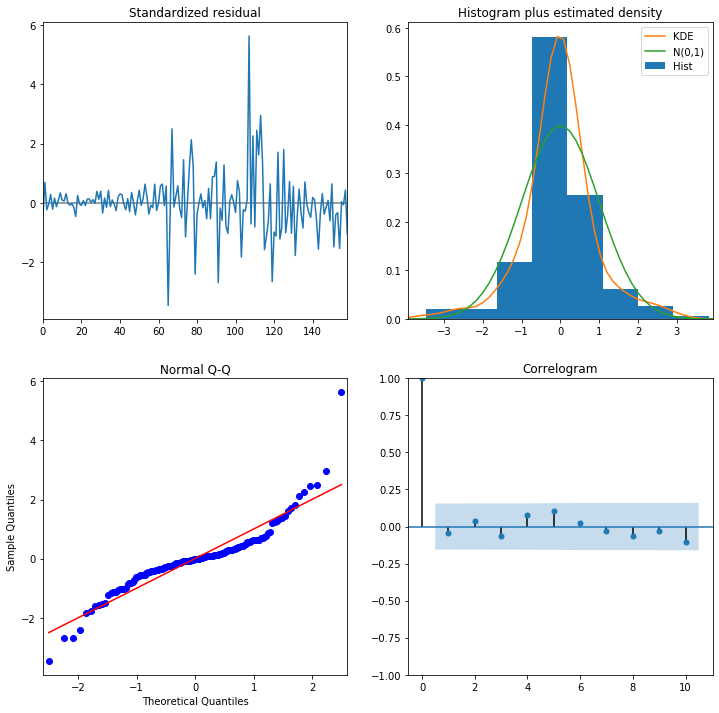

```python
# Summarize residual errors for the automated grid search ARIMA model
print(stepwise_results.summary())
stepwise_results.plot_diagnostics(figsize=(12,12))
plt.show()
```

```python
if (notifyStatus): email_notify("ARIMA automated stepwise search completed! "+datetime.now().strftime('%a %B %d, %Y %I:%M:%S %p'))
```

```python
# Do an automated random search of ARIMA parameters
n_fits = int(max_p * max_d * max_q * max_P * max_D * max_Q * 0.30)
if (seasonal_freq == 0):
    randgrid_results = pm.auto_arima(train_ts, start_p = start_p, d = start_d, start_q = start_q, max_p = max_p, max_d = max_d, max_q = max_q,
                                     seasonal = False, stepwise = False, random = True, n_fits = n_fits, max_order = None,
                                     trace = True, suppress_warnings = True, random_state = seedNum)
else:
    randgrid_results = pm.auto_arima(train_ts, start_p = start_p, d = start_d, start_q = start_q, max_p = max_p, max_d = max_d, max_q = max_q,
                                     seasonal = True, m = seasonal_freq, start_P = start_P, D = start_D, start_Q = start_Q, max_P = max_P, max_D = max_D, max_Q = max_Q,
                                     stepwise = False, random = True, n_fits = n_fits, max_order = None,
                                     trace = True, suppress_warnings = True, random_state = seedNum)
```

```
Fit ARIMA: (0, 1, 1)x(0, 1, 1, 12) (constant=True); AIC=246.988, BIC=259.264, Time=0.884 seconds
Fit ARIMA: (2, 1, 1)x(0, 1, 1, 12) (constant=True); AIC=243.095, BIC=261.508, Time=4.735 seconds
Fit ARIMA: (2, 1, 3)x(0, 1, 2, 12) (constant=True); AIC=245.653, BIC=273.273, Time=10.888 seconds
Fit ARIMA: (1, 1, 0)x(1, 1, 2, 12) (constant=True); AIC=247.033, BIC=265.447, Time=3.734 seconds
Fit ARIMA: (4, 1, 4)x(0, 1, 2, 12) (constant=True); AIC=249.014, BIC=285.841, Time=17.062 seconds
Fit ARIMA: (0, 1, 3)x(1, 1, 2, 12) (constant=True); AIC=244.078, BIC=268.629, Time=6.094 seconds
Fit ARIMA: (4, 1, 3)x(1, 1, 1, 12) (constant=True); AIC=246.007, BIC=279.765, Time=9.458 seconds
Fit ARIMA: (0, 1, 1)x(1, 1, 1, 12) (constant=True); AIC=245.154, BIC=260.499, Time=1.617 seconds
Fit ARIMA: (1, 1, 1)x(1, 1, 0, 12) (constant=True); AIC=241.734, BIC=257.079, Time=3.517 seconds
Fit ARIMA: (1, 1, 1)x(2, 1, 2, 12) (constant=True); AIC=243.651, BIC=268.202, Time=11.590 seconds
Fit ARIMA: (0, 1, 2)x(0, 1, 0, 12) (constant=True); AIC=280.246, BIC=292.521, Time=0.289 seconds
Fit ARIMA: (3, 1, 0)x(1, 1, 1, 12) (constant=True); AIC=244.116, BIC=265.599, Time=1.813 seconds
Fit ARIMA: (1, 1, 4)x(1, 1, 2, 12) (constant=True); AIC=248.073, BIC=278.762, Time=8.266 seconds
Fit ARIMA: (1, 1, 2)x(2, 1, 0, 12) (constant=True); AIC=240.986, BIC=262.469, Time=8.881 seconds
Fit ARIMA: (0, 1, 0)x(1, 1, 2, 12) (constant=True); AIC=250.702, BIC=266.046, Time=4.121 seconds
Fit ARIMA: (1, 1, 3)x(2, 1, 1, 12) (constant=True); AIC=246.152, BIC=273.772, Time=8.117 seconds
Fit ARIMA: (4, 1, 4)x(2, 1, 1, 12) (constant=True); AIC=249.777, BIC=289.673, Time=19.493 seconds
Fit ARIMA: (2, 1, 1)x(2, 1, 2, 12) (constant=True); AIC=244.154, BIC=271.774, Time=13.968 seconds
Fit ARIMA: (3, 1, 2)x(1, 1, 1, 12) (constant=True); AIC=247.466, BIC=275.086, Time=4.518 seconds
Fit ARIMA: (1, 1, 3)x(1, 1, 2, 12) (constant=True); AIC=246.072, BIC=273.692, Time=11.546 seconds
Fit ARIMA: (0, 1, 2)x(0, 1, 1, 12) (constant=True); AIC=247.117, BIC=262.462, Time=1.101 seconds
Fit ARIMA: (4, 1, 1)x(2, 1, 0, 12) (constant=True); AIC=244.824, BIC=272.444, Time=10.388 seconds
Fit ARIMA: (2, 1, 1)x(0, 1, 2, 12) (constant=True); AIC=240.939, BIC=262.421, Time=10.076 seconds
Fit ARIMA: (3, 1, 4)x(2, 1, 2, 12) (constant=True); AIC=253.136, BIC=293.031, Time=17.621 seconds
Fit ARIMA: (3, 1, 2)x(0, 1, 0, 12) (constant=True); AIC=277.202, BIC=298.684, Time=1.298 seconds
Fit ARIMA: (2, 1, 3)x(1, 1, 0, 12) (constant=True); AIC=247.487, BIC=272.038, Time=2.982 seconds
Fit ARIMA: (0, 1, 1)x(2, 1, 2, 12) (constant=True); AIC=246.874, BIC=268.357, Time=4.647 seconds
Fit ARIMA: (4, 1, 3)x(2, 1, 2, 12) (constant=True); AIC=250.706, BIC=290.601, Time=20.716 seconds
Fit ARIMA: (1, 1, 4)x(2, 1, 0, 12) (constant=True); AIC=244.301, BIC=271.921, Time=11.375 seconds
Fit ARIMA: (4, 1, 4)x(1, 1, 2, 12) (constant=True); AIC=251.218, BIC=291.114, Time=19.647 seconds
Fit ARIMA: (4, 1, 4)x(0, 1, 1, 12) (constant=True); AIC=250.870, BIC=284.628, Time=8.679 seconds
Fit ARIMA: (1, 1, 2)x(1, 1, 1, 12) (constant=True); AIC=241.752, BIC=263.234, Time=5.054 seconds
Fit ARIMA: (4, 1, 0)x(1, 1, 2, 12) (constant=True); AIC=245.801, BIC=273.421, Time=6.004 seconds
Fit ARIMA: (3, 1, 1)x(1, 1, 2, 12) (constant=True); AIC=246.026, BIC=273.646, Time=8.054 seconds
Fit ARIMA: (1, 1, 1)x(0, 1, 2, 12) (constant=True); AIC=240.315, BIC=258.728, Time=5.779 seconds
Fit ARIMA: (1, 1, 3)x(0, 1, 1, 12) (constant=True); AIC=247.838, BIC=269.320, Time=2.394 seconds
Fit ARIMA: (0, 1, 1)x(2, 1, 0, 12) (constant=True); AIC=244.231, BIC=259.576, Time=2.017 seconds
Fit ARIMA: (4, 1, 3)x(1, 1, 0, 12) (constant=True); AIC=251.464, BIC=282.153, Time=6.741 seconds
Total fit time: 295.200 seconds
```

```
                                        SARIMAX Results
===============================================================================================
Dep. Variable:                                       y   No. Observations:                  172
Model:             SARIMAX(1, 1, 1)x(0, 1, [1, 2], 12)   Log Likelihood                -114.157
Date:                                 Fri, 28 Feb 2020   AIC                            240.315
Time:                                         20:43:46   BIC                            258.728
Sample:                                              0   HQIC                           247.792
                                                 - 172
Covariance Type:                                   opg
==============================================================================
                 coef    std err          z      P>|z|      [0.025      0.975]
------------------------------------------------------------------------------
intercept      0.0016      0.003      0.599      0.549      -0.004       0.007
ar.L1          0.7042      0.095      7.399      0.000       0.518       0.891
ma.L1         -0.9160      0.066    -13.918      0.000      -1.045      -0.787
ma.S.L12      -0.5177      0.055     -9.442      0.000      -0.625      -0.410
ma.S.L24       0.1713      0.062      2.749      0.006       0.049       0.293
sigma2         0.2399      0.015     16.184      0.000       0.211       0.269
===================================================================================
Ljung-Box (Q):                       26.07   Jarque-Bera (JB):               365.83
Prob(Q):                              0.96   Prob(JB):                         0.00
Heteroskedasticity (H):              30.90   Skew:                             0.95
Prob(H) (two-sided):                  0.00   Kurtosis:                        10.18
===================================================================================

Warnings:
[1] Covariance matrix calculated using the outer product of gradients (complex-step).
```

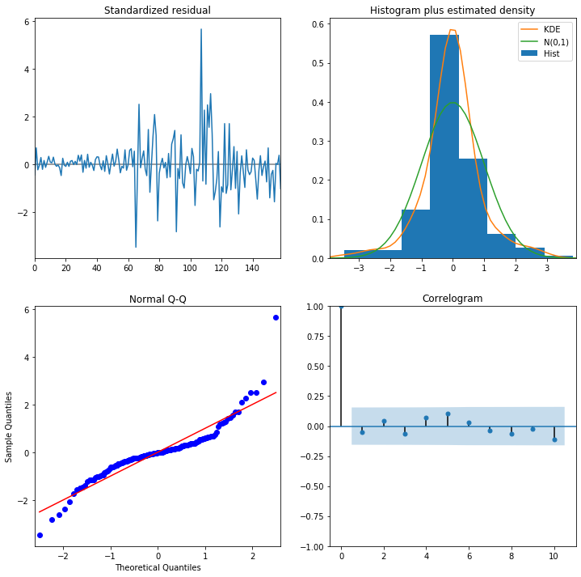

```python
# Summarize residual errors for the automated grid search ARIMA model
print(randgrid_results.summary())
randgrid_results.plot_diagnostics(figsize=(12,12))
plt.show()
```

```python
if (notifyStatus): email_notify("ARIMA automated random search completed! "+datetime.now().strftime('%a %B %d, %Y %I:%M:%S %p'))
```

```python
# Do an automated grid search of ARIMA parameters
# if (seasonal_freq == 0):
#     autogrid_results = pm.auto_arima(train_ts, start_p = start_p, d = start_d, start_q = start_q, max_p = max_p, max_d = max_d, max_q = max_q,
#                                      seasonal = False, stepwise = False, max_order = None, trace = True, suppress_warnings = True, random_state = seedNum)
# else:
#     autogrid_results = pm.auto_arima(train_ts, start_p = start_p, d = start_d, start_q = start_q, max_p = max_p, max_d = max_d, max_q = max_q,
#                                      seasonal = True, m = seasonal_freq, start_P = start_P, D = start_D, start_Q = start_Q, max_P = max_P, max_D = max_D, max_Q = max_Q,
#                                      stepwise = False, max_order = None, trace = True, suppress_warnings = True, random_state = seedNum)
```

```python
# Summarize residual errors for the automated grid search ARIMA model
# print(autogrid_results.summary())
# autogrid_results.plot_diagnostics(figsize=(12,12))
# plt.show()
```

```python
if (notifyStatus): email_notify("ARIMA automated grid search completed! "+datetime.now().strftime('%a %B %d, %Y %I:%M:%S %p'))
```

```python
# Not applicable for this iteration of the project

# Set up the function to handle the ARIMA calculation
# def Calculate_ARIMA(ns_order, ss_order):
#     startTimeModel = datetime.now()
#     aic_score, bic_score = float("inf"), float("inf")
#     if (verbose): print('Trying to fit the model with parameters:', ns_order, ss_order)
#     try:
#         if (ss_order[3] == 0): grid_model = SARIMAX(train_ts, order=ns_order)
#         else: grid_model = SARIMAX(train_ts, order=ns_order, seasonal_order=ss_order)
#         with warnings.catch_warnings():
#             warnings.simplefilter("ignore")
#             grid_results = grid_model.fit(disp = False)
#         aic_score = grid_results.aic
#         bic_score = grid_results.bic
#         if (verbose): print('Fit ARIMA: order=%s seasonal_order=%s; AIC=%.3f, BIC=%.3f, Fit time=%s' %
#               (ns_order, ss_order, aic_score, bic_score, (datetime.now() - startTimeModel)))
#         return(aic_score, bic_score)
#     except:
#         return(float("inf"), float("inf"))
```

```python
# Not applicable for this iteration of the project

# Do a manual grid search of ARIMA parameters
# best_score, best_ns_cfg, best_ss_cfg = float("inf"), None, None
# for p in range(start_p, max_p+1):
#     for d in range(start_d, max_d+1):
#         for q in range(start_q, max_q+1):
#             for P in range(start_P, max_P+1):
#                 for D in range(start_D, max_D+1):
#                     for Q in range(start_Q, max_Q+1):
#                         ns_order = (p, d, q)
#                         ss_order = (P, D, Q, seasonal_freq)
#                         aic_score, bic_score = Calculate_ARIMA(ns_order, ss_order)
#                         if (aic_score < best_score):
#                             best_ns_cfg, best_ss_cfg, best_score = ns_order, ss_order, aic_score
#                             print('A better model found: order=%s seasonal_order=%s; AIC=%.3f, BIC=%.3f' % (ns_order, ss_order, aic_score, bic_score))
# print('Best ARIMA model via manual search: order=%s seasonal_order=%s; AIC=%f' % (best_ns_cfg, best_ss_cfg, best_score))
```

```python
# Summarize residual errors for the manual ARIMA model
# manual_model = SARIMAX(train_ts, order=best_ns_cfg, seasonal_order=best_ss_cfg)
# manual_results = manual_model.fit(disp = False)
# print(manual_results.summary())
# manual_results.plot_diagnostics(figsize=(12,12))
# plt.show()
```

```python
if (notifyStatus): email_notify("ARIMA Hyperparameters Search completed! "+datetime.now().strftime('%a %B %d, %Y %I:%M:%S %p'))
```

### 4.c) Evaluate the Residual Errors

A good final check of a model is to review residual forecast errors. Ideally, the distribution of residual errors should be a Gaussian with a zero mean.

```python
# Set the ARIMA order parameters for validation and forecasting
final_ns_order = stepwise_results.order
# final_ns_order = randgrid_results.order
# final_ns_order = autogrid_results.order
# final_ns_order = best_ns_cfg
if (seasonal_freq != 0):
    final_ss_order = stepwise_results.seasonal_order
#     final_ss_order = randgrid_results.seasonal_order
#     final_ss_order = autogrid_results.seasonal_order
#     final_ss_order = best_ss_cfg
    print("Final Non-season order:", final_ns_order, 'Final Seasonal Order:', final_ss_order)
else:
    print("Final Non-season order:", final_ns_order)
```

```
Final Non-season order: (1, 1, 1) Final Seasonal Order: (2, 1, 0, 12)
```

```
                                      SARIMAX Results
===========================================================================================
Dep. Variable:                              values   No. Observations:                  216
Model:             SARIMAX(1, 1, 1)x(2, 1, [], 12)   Log Likelihood                -142.889
Date:                             Fri, 28 Feb 2020   AIC                            295.779
Time:                                     20:43:51   BIC                            312.345
Sample:                                 01-01-1960   HQIC                           302.480
                                      - 12-01-1977
Covariance Type:                               opg
==============================================================================
                 coef    std err          z      P>|z|      [0.025      0.975]
------------------------------------------------------------------------------
ar.L1          0.2991      0.166      1.806      0.071      -0.025       0.624
ma.L1         -0.5817      0.123     -4.739      0.000      -0.822      -0.341
ar.S.L12      -0.5363      0.042    -12.651      0.000      -0.619      -0.453
ar.S.L24      -0.1464      0.060     -2.458      0.014      -0.263      -0.030
sigma2         0.2351      0.012     19.243      0.000       0.211       0.259
===================================================================================
Ljung-Box (Q):                       25.12   Jarque-Bera (JB):               337.95
Prob(Q):                              0.97   Prob(JB):                         0.00
Heteroskedasticity (H):               1.86   Skew:                             0.54
Prob(H) (two-sided):                  0.01   Kurtosis:                         9.23
===================================================================================

Warnings:
[1] Covariance matrix calculated using the outer product of gradients (complex-step).
```

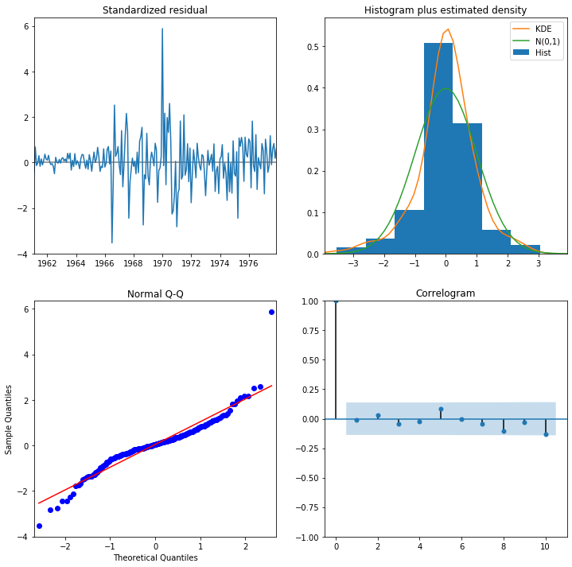

```python
# Summarize residual errors for the final ARIMA model
if (seasonal_freq != 0):
    final_model = SARIMAX(time_series, order=final_ns_order, seasonal_order=final_ss_order)
else:
    final_model = SARIMAX(time_series, order=final_ns_order)
final_results = final_model.fit(disp = False)
print(final_results.summary())
final_results.plot_diagnostics(figsize=(12,12))
plt.show()
```

```python
if (notifyStatus): email_notify("Model Fitting and Evaluation completed! "+datetime.now().strftime('%a %B %d, %Y %I:%M:%S %p'))
```

## Section 5. Finalize Model

After models have been developed and a final model selected, it must be validated and finalized. Validation is an optional part of the process, but one that provides a ‘last check’ to ensure we have not fooled or lied to ourselves.

```python
if (notifyStatus): email_notify("Model Finalization has begun! "+datetime.now().strftime('%a %B %d, %Y %I:%M:%S %p'))
```

### 5.a) Validation via In-sample Data

```python
validate_forecast = final_results.get_prediction(start = -test_size)
mean_validate_forecast = validate_forecast.predicted_mean
validate_confidence_intervals = validate_forecast.conf_int()
```

```python
# Occasionally some predicted values turned out to be < 0 but they should not be (e.g. rainfall, disease cases, etc.)
# If we have those values, we will need to set them to 0
# print(mean_validate_forecast[mean_validate_forecast < 0])
# mean_validate_forecast[mean_validate_forecast < 0] = 0
```

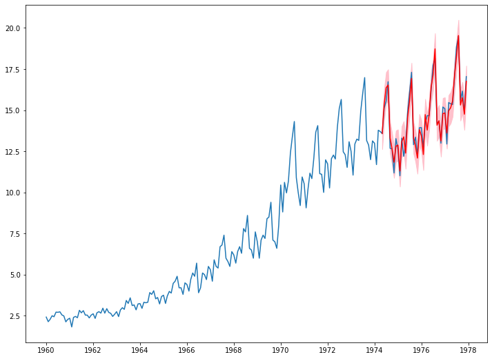

```python
plt.figure(figsize=(12,9))
plt.plot(time_series.index, time_series[target_col], label='observed')
plt.plot(mean_validate_forecast.index, mean_validate_forecast.values, color='red', label='forecast')
plt.fill_between(validate_confidence_intervals.index, validate_confidence_intervals[lower_bound],
                 validate_confidence_intervals[upper_bound], color='pink')
plt.show()
```

```python
# Evaluate RMSE for the validation data
y_test = time_series[-test_size:]
predictions = mean_validate_forecast.values
for i in range(y_test.shape[0]):
    print(y_test.index[i], ' | ', y_test.iloc[i,0], ' | ', predictions[i])
print('RMSE from the validation data is: %.3f' % math.sqrt(mean_squared_error(y_test, predictions)))
```

```
1974-05-01 00:00:00  |  13.57  |  13.58193876568233
1974-06-01 00:00:00  |  15.12  |  15.353211060204883
1974-07-01 00:00:00  |  15.55  |  16.357490169055733
1974-08-01 00:00:00  |  16.73  |  16.527192389401343
1974-09-01 00:00:00  |  12.68  |  13.304114480329403
1974-10-01 00:00:00  |  12.65  |  12.660317028097428
1974-11-01 00:00:00  |  11.18  |  11.833255092730765
1974-12-01 00:00:00  |  13.27  |  12.808453228335354
1975-01-01 00:00:00  |  12.64  |  12.873719338504213
1975-02-01 00:00:00  |  11.01  |  11.301692294804651
1975-03-01 00:00:00  |  13.3  |  13.072518379185745
1975-04-01 00:00:00  |  12.19  |  13.376508993780899
1975-05-01 00:00:00  |  12.91  |  12.387974822215128
1975-06-01 00:00:00  |  14.9  |  14.557358612936916
1975-07-01 00:00:00  |  16.1  |  15.565294117325552
1975-08-01 00:00:00  |  17.3  |  16.925221462870145
1975-09-01 00:00:00  |  12.9  |  13.302093007001938
1975-10-01 00:00:00  |  13.36  |  12.819878024387862
1975-11-01 00:00:00  |  12.26  |  12.085618257356263
1975-12-01 00:00:00  |  13.93  |  13.812911895149503
1976-01-01 00:00:00  |  13.94  |  13.438655429472139
1976-02-01 00:00:00  |  12.75  |  12.30551665033599
1976-03-01 00:00:00  |  14.19  |  14.73014725077428
1976-04-01 00:00:00  |  14.67  |  13.788859575440622
1976-05-01 00:00:00  |  14.66  |  14.72261613396231
1976-06-01 00:00:00  |  16.21  |  16.401393742193676
1976-07-01 00:00:00  |  17.72  |  17.12759476943259
1976-08-01 00:00:00  |  18.15  |  18.72451112165045
1976-09-01 00:00:00  |  14.19  |  14.085753309649068
1976-10-01 00:00:00  |  14.33  |  14.357233739757168
1976-11-01 00:00:00  |  12.99  |  13.12573232592215
1976-12-01 00:00:00  |  15.19  |  14.787264759495667
1977-01-01 00:00:00  |  15.09  |  14.82700333151273
1977-02-01 00:00:00  |  12.94  |  13.607668467832132
1977-03-01 00:00:00  |  15.46  |  14.963941591504451
1977-04-01 00:00:00  |  15.39  |  15.144946184412033
1977-05-01 00:00:00  |  15.34  |  15.549978357292776
1977-06-01 00:00:00  |  17.02  |  17.09184746185865
1977-07-01 00:00:00  |  18.85  |  18.28033421536007
1977-08-01 00:00:00  |  19.49  |  19.537888634521405
1977-09-01 00:00:00  |  15.61  |  15.31327437083171
1977-10-01 00:00:00  |  16.16  |  15.756472800810162
1977-11-01 00:00:00  |  14.84  |  14.7525912697924
1977-12-01 00:00:00  |  17.04  |  16.750084252716892
RMSE from the validation data is: 0.444
```

### 5.b) Forecasting Out-of-Sample Data

```python
if (seasonal_freq != 0):
    forecast_size = seasonal_freq
else:
    forecast_size = 1
final_forecast = final_results.get_forecast(steps = forecast_size)
mean_final_forecast = final_forecast.predicted_mean
final_confidence_intervals = final_forecast.conf_int()
print("The forecasted values are:\n\n", mean_final_forecast)
```

```
The forecasted values are:

 1978-01-01    16.803278
1978-02-01    15.073229
1978-03-01    17.129321
1978-04-01    17.118745
1978-05-01    17.196282
1978-06-01    18.870746
1978-07-01    20.483646
1978-08-01    21.123749
1978-09-01    17.136401
1978-10-01    17.513357
1978-11-01    16.217775
1978-12-01    18.340163
Freq: MS, dtype: float64
```

```python
# Occasionally some predicted values turned out to be < 0 but they should not be (e.g. rainfall, disease cases, etc.)
# If we have those values, we will need to set them to 0
# print(mean_final_forecast[mean_final_forecast < 0])
# mean_final_forecast[mean_final_forecast < 0] = 0
```

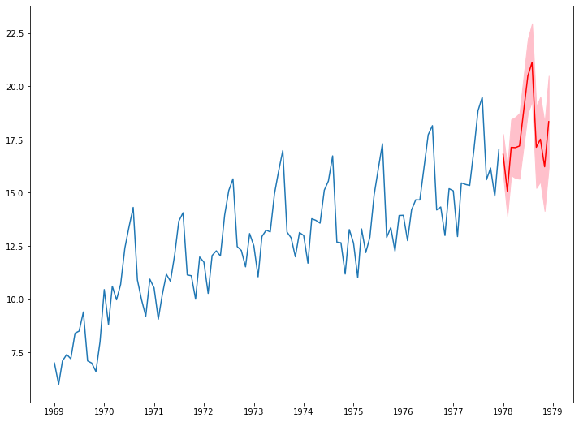

```python
plt.figure(figsize=(12,9))
halfway_point = int(time_series.index.size / 2)
plt.plot(time_series.index[halfway_point:], time_series[target_col][halfway_point:], label='observed')
plt.plot(mean_final_forecast.index, mean_final_forecast.values, color='red', label='forecast')
plt.fill_between(final_confidence_intervals.index, final_confidence_intervals[lower_bound],
                 final_confidence_intervals[upper_bound], color='pink')
plt.show()
```

```python
if (notifyStatus): email_notify("Model Finalization completed! "+datetime.now().strftime('%a %B %d, %Y %I:%M:%S %p'))
```

```python
print ('Total time for the script:',(datetime.now() - startTimeScript))
```

```
Total time for the script: 0:07:05.711510
```